# Boundary lines for yield gap analysis: Revisiting Fermont et al. (2009)

Tomás Roquette Tenreiro$^a$ (PhD) and João Vasco Silva$^b$ (PhD)

$^a$SISTAGRO - Systems Engineering in Agriculture

$^b$CIMMYT-Zimbabwe & WUR-PPS

16-May-2023

# **Introduction**

Boundary line analysis is a powerful concept in agronomy (Webb 1972) as it can be used to explain yield gaps in farmers’ fields. From a conceptual standpoint, different approaches have been proposed for boundary line analysis over the past decades, which can be grouped in three main methodological families. The first estimates the boundary lines “manually and by eye” (e.g., French & Schultz (1984)). The second relies on statistical methods, encompassing grouping data and fitting ‘splines’, to estimate the boundary line (e.g., Fermont *et al.* (2009)). Lastly, econometric techniques including quantile regression and stochastic frontier analysis have also been used to estimate boundary lines (e.g., Silva *et al.* (2017)).

Herewith, we focused on the boundary line approach encompassing grouping data and fitting of ‘splines’ to farmer field data. The general features of this approach include (1) identification of boundary points, (2) estimation of a continuous function characterizing the boundary points, and (3) yield gap analysis for each factor and across factors. This type of boundary line analysis has been used widely in the past years across a number of crops and geographies (e.g., Casanova *et al.* (1999); Shatar & McBratney (2004); Fermont *et al.* (2009); Wairegi *et al.* (2010)). Its statistical nature (e.g., Fermont *et al.* (2009)) makes it suitable for reproducible research and easy to interpret by agronomists.

The use of the method for yield gap decomposition was best described by Wairegi *et al.* (2010). After estimating boundary lines for individual production factors, von Liebig’s law of the minimum is used to identify the production factor limiting crop yield most. This is done for each field as Ymin = min(Yx1, Yx2, …, Yxn), where Yxn is the yield predicted with the boundary line for a given production factor. Estimation of Ymin allows identifying the limiting factor to crop yield and decomposing the yield gap into an ‘identified yield gap’ (IYG) and an ‘unexplained yield gap’ (UYG) in each field. IYG is defined as the difference between the water-limited yield and the Ymin. UYG is defined as the difference between Ymin and the reported actual yield.

This workflow documents in a reproducible way the concept of boundary line analysis of Fermont *et al.* (2009) on the original dataset for cassava cropping systems in Eastern Africa. Fermont *et al.* (2009) conducted a number of household surveys and on-farm trials in Uganda and western Kenya to unravel the importance of abiotic, biotic and associated crop management constraints to cassava production. Clear boundary lines between cassava yield and growing season rainfall, soil fertility, soil texture, and pest, disease and weed management practices, which were identified as the key constraints to cassava production in East Africa.

# **Load required R packages**

First, we need to load the R packages needed to run this workflow.

```r
# package names
packages <- c("splines", "Metrics", "dplyr", "tidyr", "knitr", "reshape2", "ggplot2", "DT")

# install packages
installed_packages <- packages %in% rownames(installed.packages())
if (any(installed_packages == FALSE)){
  install.packages(packages[!installed_packages])}

# load packages
invisible(lapply(packages, library, character.only = TRUE))
```

# **Crop field data**

```r
# read .csv file with data
file <- 'https://raw.githubusercontent.com/jvasco323/EiA_BLA_workflow/main/fermont_etal_final.csv'
data <- read.csv(url(file))

# list variables of interest for visualization
str(data)
```

```
## 'data.frame':    122 obs. of  22 variables:
##  $ year           : int  2005 2005 2005 2005 2005 2005 2005 2005 2005 2005 ...
##  $ Trial          : chr  "NOT" "NOT" "NOT" "NOT" ...
##  $ Site           : chr  "Nambale" "Nambale" "Nambale" "Nambale" ...
##  $ Farm.no.       : chr  "41" "42" "43" "44" ...
##  $ yld_t0         : num  17.8 9.5 33.8 18 18.5 ...
##  $ pH_soil        : num  5.2 5.3 5.3 5.3 5.2 5.2 5.4 5.2 5.9 5.5 ...
##  $ SOC            : num  9.66 8.85 9.4 9.72 9.14 ...
##  $ totN_soil      : num  0.516 0.509 0.539 0.545 0.602 ...
##  $ P_soil         : num  3.15 2.29 2.36 3.41 3.28 ...
##  $ K_soil         : num  0.124 0.14 0.124 0.142 0.512 ...
##  $ Ca_soil        : num  0.409 0.313 0.365 1.412 1.634 ...
##  $ Mg_soil        : num  0.236 0.555 0.165 0.1 0.915 ...
##  $ CBB_T0_9       : num  93.8 147.5 172.5 117.9 151.5 ...
##  $ CGM_T0_9       : num  120 210 128 131 183 ...
##  $ CAD_T0_9       : num  0 0 3.75 0 13.24 ...
##  $ RF_tot         : int  2460 2460 2460 2460 2460 2460 2460 2460 2460 2377 ...
##  $ RF0_6M         : int  1107 1107 1107 1107 1107 1107 1107 1107 1107 1306 ...
##  $ RF_.d          : int  144 144 144 144 144 144 144 144 144 165 ...
##  $ sand           : num  54 64 52 50 52 66 58 58 60 58 ...
##  $ clay           : num  33 23 33 33 31 21 27 27 20 23 ...
##  $ silt           : num  13 13 15 17 17 13 15 15 20 19 ...
##  $ days_to_harvest: int  397 397 397 397 397 397 397 397 397 398 ...
```

# **Data manipulation**

In the chunk of code below, we exclude observations with cassava yields above 30 t/ha based on the yield distribution observed in the data.

```r
# remove outliers
data <- subset(data, yld_t0 < 30)
```

# **Descriptive statistics**

Descriptive statistics of actual cassava yield and crop management practices over the two cropping seasons used in the analysis are provided below. The actual yield of cassava across the study region was on average 13.9 t/ha. Local soils were moderately acidic (pH < 5.8) and growing season rainfall was on average 1728 mm. Soil clay content and soil organic C were on average 27.2% and 10.5 mg/kg, respectively.

| Variable | Mean 2004 | Mean 2005 | StDev 2004 | StDev 2005 |
| --- | --- | --- | --- | --- |
| Soil clay content (%) | 26.5 | 27.8 | 8.4 | 9.5 |
| Days to harvest (d) | 368.6 | 387.2 | 37.7 | 11.7 |
| Soil pH | 5.8 | 5.7 | 0.5 | 0.4 |
| Growing season rainfall (mm) | 1642.8 | 1814.1 | 318.6 | 469.6 |
| Soil organic C (mg/kg) | 10.7 | 10.3 | 3.9 | 4.2 |
| Cassava yield (t/ha) | 12.9 | 14.9 | 6 | 6.4 |

# **Step 1: Field selection**

The function in the next chunk of code was developed to categorize the x-variable into 10 groups with the same number of observations and to obtain the maximum yield (ymax) for each group. The latter can be obtained with two approaches. The first, **maximum**, defines ymax as the maximum yield observed in each of the 10 groups. The second, **95_quantile**, defines ymax as the average actual yield in the top 5th quantile of the yield distribution. The selection of the most appropriate approach depends on the yield variability within each of the 10 groups and on the error associated with the fitted boundary line (see next section).

In our view, the selection of ymax based on the absolute maximum yield observed in each group is more appropriate for denser scatters where no clear outliers in crop yield can be identified. Defining ymax based on the top 5th quantile of actual yields for each group is a more conservative approach, suitable for datasets with potential outliers in crop yield. In such cases, the mean actual yield in the top 5th quantile will reduce the individual weight of single observations, which might be overestimated.

It is important to note that boundary lines estimated with splines tend to underestimate ymax for most initial x-intervals (i.e., where ‘y’ shows a large response to a variation of ‘x’). Thus, the use of the mean actual yield of the top 5th quantile should be avoided every time there is enough confidence on the reported ‘y’ values.

```r
bl_points <- function(df, xvar, approach){

   # select the x variable of interest
   df <- df[,c("yld_t0", xvar)]

   # modify column names for generic use
   colnames(df)[1] = "Y"
   colnames(df)[2] = "X"
   df <- subset(df, X>0, select=c(Y, X)) # why x > 0?

   # 'NULL' values are excluded to avoid data transformation problems and calculation failures
   # correct NA values for both Y and X variables
   df$Y[is.na(df$Y)] <- mean(df$Y, na.rm=T)
   df$X[is.na(df$X)] <- mean(df$X, na.rm=T)

   # split X variable in 10 quantiles (Fermont et al., 2009)
   x_0.1 <- subset(df, X <= quantile(X, 0.1))
   x_0.2 <- subset(df, X > quantile(X, 0.1) & X <= quantile(X, 0.2))
   x_0.3 <- subset(df, X > quantile(X, 0.2) & X <= quantile(X, 0.3))
   x_0.4 <- subset(df, X > quantile(X, 0.3) & X <= quantile(X, 0.4))
   x_0.5 <- subset(df, X > quantile(X, 0.4) & X <= quantile(X, 0.5))
   x_0.6 <- subset(df, X > quantile(X, 0.5) & X <= quantile(X, 0.6))
   x_0.7 <- subset(df, X > quantile(X, 0.6) & X <= quantile(X, 0.7))
   x_0.8 <- subset(df, X > quantile(X, 0.7) & X <= quantile(X, 0.8))
   x_0.9 <- subset(df, X > quantile(X, 0.8) & X <= quantile(X, 0.9))
   x_1.0 <- subset(df, X > quantile(X, 0.9) & X <= quantile(X, 1.0))

   # define boundary points for each quantile based on maximum value
   if(approach == 'maximum'){
    blp_0.0 <- subset(x_0.1, X == min(X)) #  briefly explain why needed
    blp_0.1 <- subset(x_0.1, Y == max(Y))
    blp_0.2 <- subset(x_0.2, Y == max(Y))
    blp_0.3 <- subset(x_0.3, Y == max(Y))
    blp_0.4 <- subset(x_0.4, Y == max(Y))
    blp_0.5 <- subset(x_0.5, Y == max(Y))
    blp_0.6 <- subset(x_0.6, Y == max(Y))
    blp_0.7 <- subset(x_0.7, Y == max(Y))
    blp_0.8 <- subset(x_0.8, Y == max(Y))
    blp_0.9 <- subset(x_0.9, Y == max(Y))
    blp_1.0 <- subset(x_1.0, Y == max(Y))

   # define boundary points for each quantile based on yields in given quantile
   } else if(approach == '95_quantile'){
    blp_0.0 <- subset(x_0.1, X == min(X))
    blp_0.1 <- subset(x_0.1, Y > quantile(Y, 0.95))
    blp_0.2 <- subset(x_0.2, Y > quantile(Y, 0.95))
    blp_0.3 <- subset(x_0.3, Y > quantile(Y, 0.95))
    blp_0.4 <- subset(x_0.4, Y > quantile(Y, 0.95))
    blp_0.5 <- subset(x_0.5, Y > quantile(Y, 0.95))
    blp_0.6 <- subset(x_0.6, Y > quantile(Y, 0.95))
    blp_0.7 <- subset(x_0.7, Y > quantile(Y, 0.95))
    blp_0.8 <- subset(x_0.8, Y > quantile(Y, 0.95))
    blp_0.9 <- subset(x_0.9, Y > quantile(Y, 0.95))
    blp_1.0 <- subset(x_1.0, Y > quantile(Y, 0.95))}

   # bind subsets
   blp_df <- rbind(blp_0.0, blp_0.1, blp_0.2, blp_0.3, blp_0.4, blp_0.5,
                   blp_0.6, blp_0.7, blp_0.8, blp_0.9, blp_1.0)
   return(blp_df)}
```

# **Step 2: Boundary lines**

The first step to fit a boundary line is to select the independent variables of interest. Independent variables with a discrete distribution should be avoided as these won’t allow for a reliable estimation of ymax for a range of x-values. The variables ‘CAD_T0_9’, ‘RF_tot’, ‘RF0_6M’, ‘RF_.d’ and ‘days_to_harvest’ in the dataset of Fermont *et al.* (2009) do not have a continuous distribution of values, which is problematic for boundary line analysis because many observations would be associated with the same ymax. Therefore, we decided not to include these variables from the analysis presented here.

```r
# four variables considered for illustrative purposes
variables <- c("pH_soil", "totN_soil", "P_soil", "clay")
```

Before estimating the boundary lines in the next chunk of code, we create empty dataframes to bind all the new data generated in the for loop used for this purpose.

```r
blp_new <- c()
data_new <- c()
rmse_df <- c()
```

A generic six-step procedure, documented in the chunk of code below, was implemented to estimate boundary lines for individual production factors. In **step 1**, a new column is created in the dataframe of each production factor. In **step 2**, this new column stores the corresponding boundary lines points selected through the approach “maximum”. A statistical model is fitted to the data using glm() in **step 3** for each group of boundary line points. The fitted model is further used in **step 4** to estimate ymax and to store its values in the dataframe containing the original data (“data_subset”) and in the dataframe created for each production factor (“data.bla”). After adding a new column (‘y_pred’) to both dataframes, the root mean square error (“rmse”) is computed in **step 5** to compare the maximum observed yields against the maximum predicted yields by the boundary line. Finally, dataframes are bound together in **step 6**. Three dataframes are produced with this procedure:

- “blp_new” includes only the boundary line points (one column with the observed yields plus n columns, each showing the predicted ymax for each i variable);
- “data_new” includes all observations as per the original data (one column with the observed yields plus n columns, each showing the predicted ymax for each i variable);
- “rmse_df” including the root mean square errors estimated for the boundary lines fitted for each production factor (one column associated with each boundary line for each i-variable).

```r
for(i in unique(variables)){
  # print(i)

  # 1) select data
  data_subset <- data[,c("year", "Trial", "Site", "Farm.no.", "yld_t0", i)]
  colnames(data_subset)[5] = "Y"
  colnames(data_subset)[6] = "X"
  data_subset$variable <- i

  # 2) estimate boundary line points
  data.bla <- bl_points(data, i, approach="maximum")
  data.bla$variable <- i

  # 3) create predictive model
  model <- glm(Y ~ ns(X, df = 2), data = data.bla)
  # print(model)

  # 4) predict y_max
  # boundary points only
  data.bla$y_pred <- predict(model, newdata = data.bla)
  # raw data
  data_subset$y_pred <- predict(model, newdata = data_subset)

  # 5) error assessment
  rmse_value <- rmse(data.bla$Y, data.bla$y_pred)

  # 6) bind all data together
  blp_new <- rbind(blp_new, data.bla)
  data_new <- rbind(data_new, data_subset)
  rmse_df <- rbind(rmse_df, cbind(i, rmse_value))}
```

The boundary line fitted between cassava yield and soil pH in water is illustrated below.

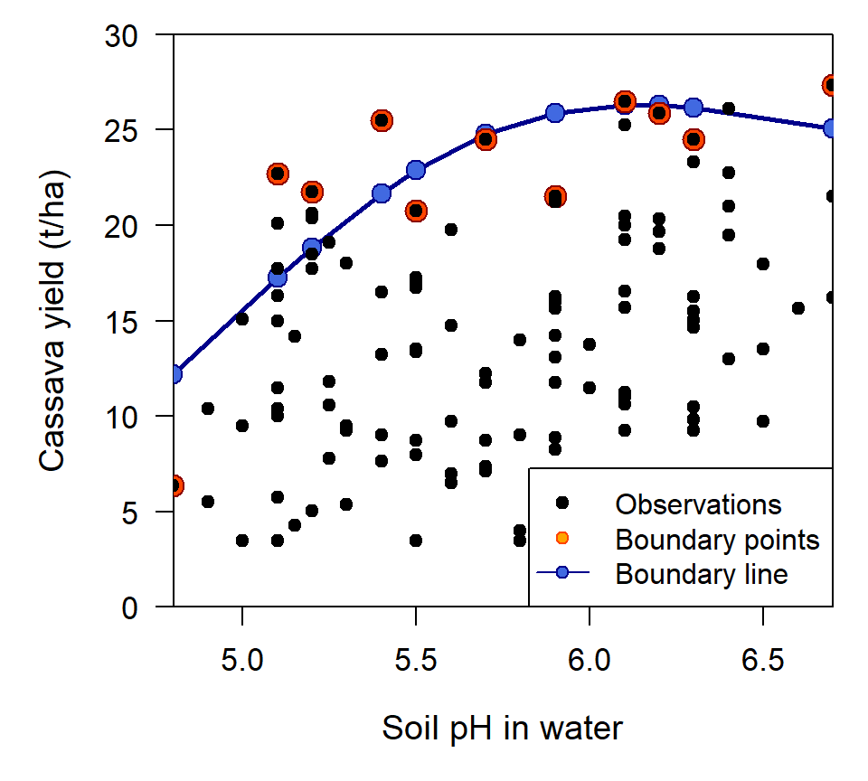

```r
# subset for variable of interest
pH <- subset(blp_new, variable =='pH_soil')
pH <- pH[order(pH$X),]
pH_original <- subset(data_new, variable =='pH_soil')

# make plot
par(mfrow=c(1,1), mar=c(5,5,1,1), las=1, xaxs='i', yaxs='i', cex.axis=1.1, cex.lab=1.2)
plot(pH$X, pH$y_pred, ylim=c(0,30), xlab='Soil pH in water', ylab='Cassava yield (t/ha)')
lines(pH$X, pH$y_pred, lty=1, col='darkblue', lwd=2.5)
points(pH$X, pH$y_pred, pch=21, cex=1.5, col='darkblue', bg='royalblue')
points(pH$X, pH$Y, pch=21, cex=1.75, col='darkred', bg='orangered')
points(pH_original$X, pH_original$Y, pch=21, cex=1, col='black', bg='black')
legend('bottomright', legend=c('Observations', 'Boundary points', 'Boundary line'),
       lty=c(NA,NA,1), pch=c(21,21,21),
       col=c('black', 'orangered', 'darkblue'), pt.bg=c('black', 'orange', 'royalblue'))
```

# **Step 3: Yield gap analysis**

The first step for the yield gap analysis is to obtain ymin and the corresponding limiting factor (i.e., the corresponding x-variable with the lowest BL predicted yield for a certain observed yield) for each field. This is done with the chunk of code below.

```r
# reshape df
data_ygd <- dcast(data_new, year + Trial + Site + Farm.no. + Y ~ variable, value.var='y_pred')
data_ygd$y_pred_min <- apply(data_ygd[6:9], 1, min)
data_ygd$limiting_factor <- names(data_ygd[6:9])[apply(data_ygd[6:9], 1, which.min)]
```

Following, we estimate the ‘identified yield gap’ (IYG) and the ‘unexplained yield gap’ (UYG) according to Wairegi *et al.* (2010).

```r
# decompose yg
data_ygd$IYG <- max(data_ygd$Y, na.rm=T) - data_ygd$y_pred_min
data_ygd$UYG <- data_ygd$y_pred_min - data_ygd$Y
```

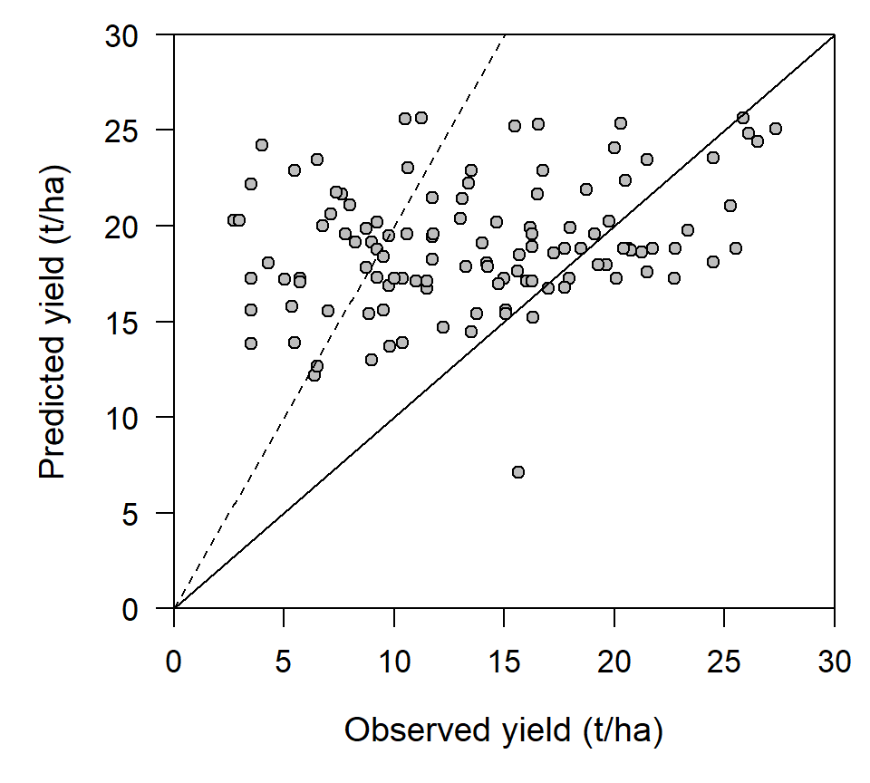

```r
# plot yield gaps
par(mfrow=c(1,1), mar=c(5,5,1,1), las=1, xaxs='i', yaxs='i', cex.axis=1.1, cex.lab=1.2)
plot(data_ygd$Y, data_ygd$y_pred_min, xlim=c(0, 30), ylim=c(0, 30), xlab='Observed yield (t/ha)', ylab='Predicted yield (t/ha)')
points(data_ygd$Y, data_ygd$y_pred_min, pch=21, cex=1, col='black', bg='grey')
abline(a=0, b=1, lty=1)
abline(a=0, b=2, lty=2)
```

```r
# see limiting factors
table(data_ygd$limiting_factor)
```

```
##
##      clay    P_soil   pH_soil totN_soil
##        16        34        29        39
```

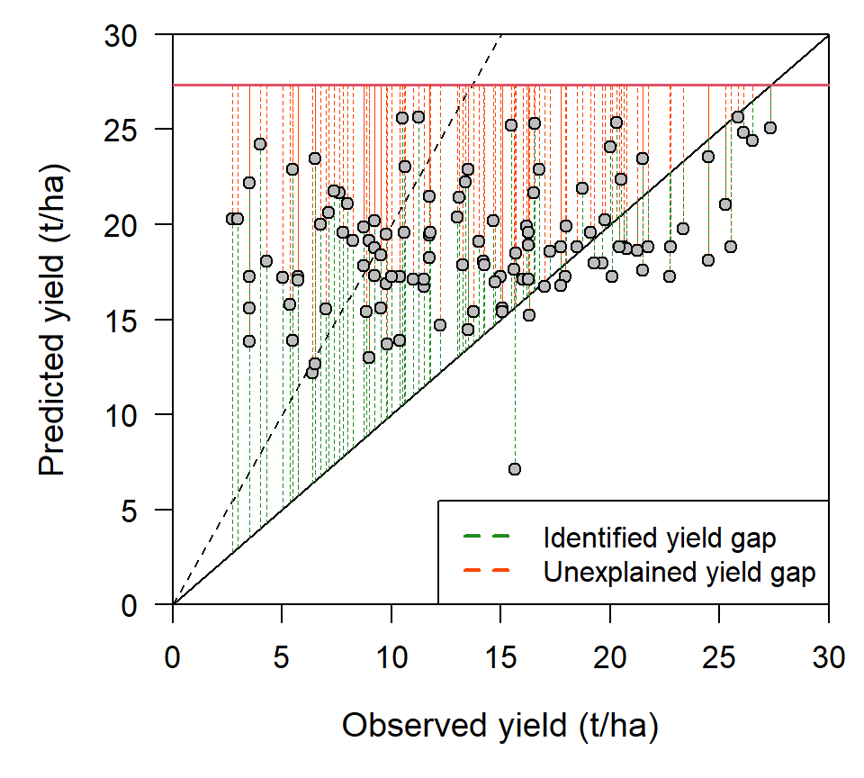

```r
# plot IYG and UYG
par(mfrow=c(1,1), mar=c(5,5,1,1), las=1, xaxs='i', yaxs='i', cex.axis=1.1, cex.lab=1.2)
plot(data_ygd$Y, data_ygd$y_pred_min, xlim=c(0, 30), ylim=c(0, 30), xlab='Observed yield (t/ha)', ylab='Predicted yield (t/ha)')
abline(a=0, b=1, lty=1)
abline(a=0, b=2, lty=2)
abline(h=max(data_ygd$Y), lty=1, col=2, lwd=1.5)
segments(x0=data_ygd$Y, x1=data_ygd$Y, y0=data_ygd$y_pred_min, y1=data_ygd$y_pred_min+data_ygd$IYG, lwd=0.7, lty=2, col='orangered')
segments(x0=data_ygd$Y, x1=data_ygd$Y, y0=data_ygd$y_pred_min-data_ygd$UYG, y1=data_ygd$y_pred_min, lwd=0.7, lty=2, col='forestgreen')
points(data_ygd$Y, data_ygd$y_pred_min, pch=21, cex=1, col='black', bg='grey')
legend('bottomright', legend=c('Identified yield gap', 'Unexplained yield gap'), lty=2, lwd=2, col=c('forestgreen', 'orangered'))
```

___

# **Recommendations**

The main **disadvantages** of boundary line anaysis can be summarized as follows:

- The method requires a thorough control of outliers, particularly on crop yield. Thus, the error of measured yields must be minimal. If this cannot be ensured then boundary points should be identified as the top 5th quantile of actual yields, rather than as the maximum yield, within each group of the independent variable.
- The interpretability of the data cannot be purely statistical as the patterns of the ‘splines’ need to be contextualized through agronomic knowledge.
- Independent variables must cover a wide range of variation, i.e., they must show a considerable range of values and accommodate a large variation in crop yield after being segmented in smaller groups.
- The segmentation of x-variables into groups with a similar number of observations is somewhat arbitrary. The influence of such decision on final results must be checked.
- Independent variables with discrete distributions (or with a lot of zero values) cannot be considered in this type of analysis. These may still be used partitioning the dataset into homogeneous groups (e.g., irrigated vs. rainfed) depending on the sample of each subset.

# **Acknowledgments**

We thank Ken Giller (WUR-PPS) and Piet van Asten (Olam International) for sharing the original data showcased in this workflow. The development of this notebook was possible thanks to the financial support from the OneCGIAR initiative on *Excellence in Agronomy*. For further support and questions on how to implement this workflow to other data sets, please contact J.V. Silva (**j.silva@cgiar.org**).

# **References**

Casanova, D., Goudriaan, J., Bouma, J. & Epema, G.F. (1999). Yield gap analysis in relation to soil properties in direct-seeded flooded rice. *Geoderma*, 91, 191–216.

Fermont, A.M., van Asten, P.J.A., Tittonell, P., van Wijk, M.T. & Giller, K.E. (2009). [Closing the cassava yield gap: An analysis from smallholder farms in East Africa](https://doi.org/10.1016/j.fcr.2009.01.009). *Field Crops Research*, 112, 24–36.

French, R.J. & Schultz, J.E. (1984). [Water use efficiency of wheat in a Mediterranean-type environment. I. The relation between yield, water use and climate.](https://doi.org/10.1071/AR9840743) *Australian Journal of Agricultural Research*, 35, 743–764.

Shatar, T.M. & McBratney, A.B. (2004). [Boundary-line analysis of field-scale yield response to soil properties](https://doi.org/10.1017/S0021859604004642). *The Journal of Agricultural Science*, 142, 553–560.

Silva, J.V., Reidsma, P., Laborte, A.G. & van Ittersum, M.K. (2017). [Explaining rice yields and yield gaps in Central Luzon, Philippines: An application of stochastic frontier analysis and crop modelling](https://doi.org/10.1016/j.eja.2016.06.017). *European Journal of Agronomy*, 82, Part B, 223–241.

Wairegi, L.W.I., van Asten, P.J.A., Tenywa, M.M. & Bekunda, M.A. (2010). [Abiotic constraints override biotic constraints in East African highland banana systems](https://doi.org/10.1016/j.fcr.2010.02.010). *Field Crops Research*, 117, 146–153.

Webb, R.A. (1972). [Use of the boundary line in the analysis of biological data](https://doi.org/10.1080/00221589.1972.11514472). *Journal of Horticultural Science*, 47, 309–319.